# Recalling Words

```r
# Play the chunk above and this one to get the data into your Console
View(Friendly)
?Friendly
```

## Background

Many teachers and other educators are interested in understanding how to best deliver new content to students. In general, they have two choices of how to do this.

1. The Meshed Approach
   - Deliver new content while simultaneously reviewing previously understood content.
2. The Before Approach
   - Deliver new content after fully reviewing previously understood content.

A study was performed to determine whether the *Meshed* or *Before* approaches to delivering content had any positive benefits on memory recall.

##### The Experiment (click to view)

##### The Data (click to view)

```r
dat <- Friendly
datSFR <- subset(dat, condition == "SFR")
datBefore <- subset(dat, condition == "Before")
datMeshed <- subset(dat, condition == "Meshed")
```

## Question and Hypothesis

The question that the following tests are trying to answer is, “Which of the three methods (SFR, Before, or Meshed) mentioned are most effective in helping a student memorize information?” This is intriguing since proving that one method is more affective than another would influence teaching styles to help students. My hypothesis is that the Before group will perform the best when compared with the other groups, which means that I believe that the three methods will not all be stochastically equal.

$$H_o: the\ distributions\ are\ stochastically\ equal$$
$$H_a: the\ Before\ group\ is\ stochastically\ greater\ than\ the\ SFR\ and\ the\ Meshed\ groups$$

I will test my hypothesis by performing a wilcoxon rank sum test. I will also display the results through the use of box plots.

## My Tests and Visualizations

#### Testing the data for normal distribution

```r
par(mfrow=c(1,3))
qqPlot(datSFR$correct, main = "SFR Group", ylab = "Correct Number of Words Recalled")
```

```
## [1] 7 1
```

```r
qqPlot(datBefore$correct, main = "Before Group", ylab = "Correct Number of Words Recalled")
```

```
## [1] 6 7
```

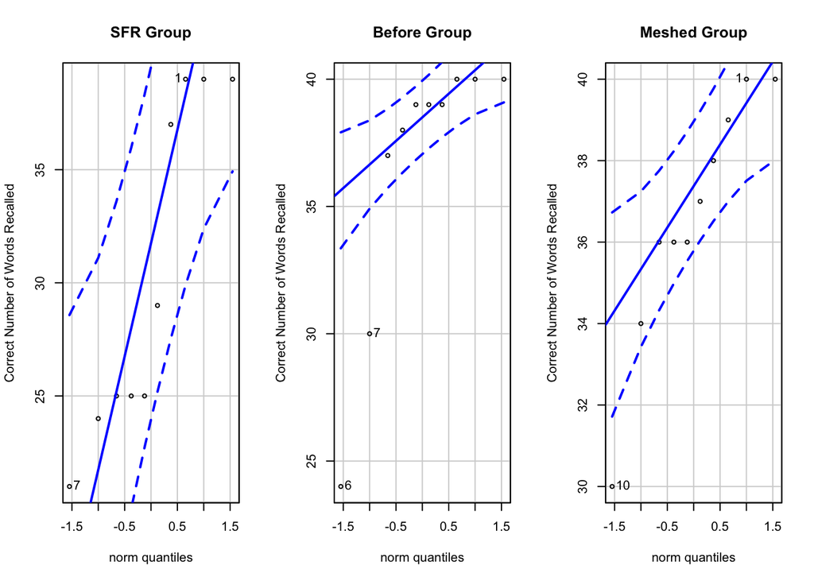

```
## [1] 10  1
```

```r
qqPlot(datMeshed$correct, main = "Meshed Group", ylab = "Correct Number of Words Recalled")
```

#### Testing to see which method might be most effective

```r
wilcox.test(datBefore$correct,datSFR$correct,mu= 0,alternative = "greater", conf.level = .975)
```

```
##
##  Wilcoxon rank sum test with continuity correction
##
## data:  datBefore$correct and datSFR$correct
## W = 76.5, p-value = 0.02278
## alternative hypothesis: true location shift is greater than 0
```

```r
wilcox.test(datBefore$correct,datMeshed$correct,mu=0,alternative="greater", conf.level = .975)
```

```
##
##  Wilcoxon rank sum test with continuity correction
##
## data:  datBefore$correct and datMeshed$correct
## W = 62, p-value = 0.189
## alternative hypothesis: true location shift is greater than 0
```

#### Explanation

When comparing the SFR group and the before group, we can reject the null, but with the Before group and the Meshed group, we fail to reject the null.

#### Box Plots to further illustrate the wilcox test results

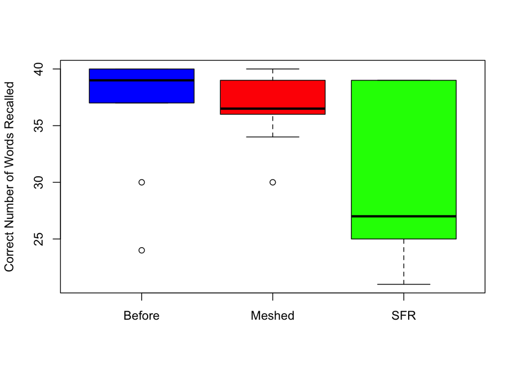

```r
boxplot(dat$correct ~ dat$condition, col = c("blue","red","green"), ylab="Correct Number of Words Recalled")
```

## Conclusion

```r
wilcox.test(datMeshed$correct, datSFR$correct, mu = 0,alternative = "greater", conf.level =.975)
```

```
##
##  Wilcoxon rank sum test with continuity correction
##
## data:  datMeshed$correct and datSFR$correct
## W = 72, p-value = 0.05075
## alternative hypothesis: true location shift is greater than 0
```

The above results show that the Meshed group is not stochastically greater than the SFR group.

The reason I set the alpha levels at .025 was because the original test was to see if the Before group was stochastically greater than both the Meshed and the SFR groups and since I am making two comparisons, I wanted to lower the alpha levels so the overall alpha level is near .05. In conclusion, the Before group was not stochastically greater than both the Meshed and SFR groups and I failed to reject the null hypothesis overall.